# AS05_Homework_Web-Scraping-JSON

楊紫希 60988016I 師大大傳

2022/04/28

## 作業目的

這份作業希望能夠讓你熟悉 Web Scraping 的流程，這週的重點會著重在 JSON。

## A. scrape 104 & compare salary（50分）

接續老師錄製的影片，請到 [104 人力銀行](https://www.104.com.tw/jobs/main/)，爬取「軟體工程」和「資料科學」兩種職業的搜尋結果，扣除面議的薪資不計，繪製圖表比較這 2 種職業的薪資差異，請自行思考適合的圖表類型與指標。

你的程式碼應該包含 3 個部分：爬資料、清理資料如薪資與年資等欄位、視覺化，有些流程可能需要借助你的主觀判斷，請盡量搭配文字適度解釋你處理資料的過程。另外，建議你爬好資料之後，可以自行創建並存取在 `data/AS05/` 資料夾當中，以免每次 knit 都要重爬。

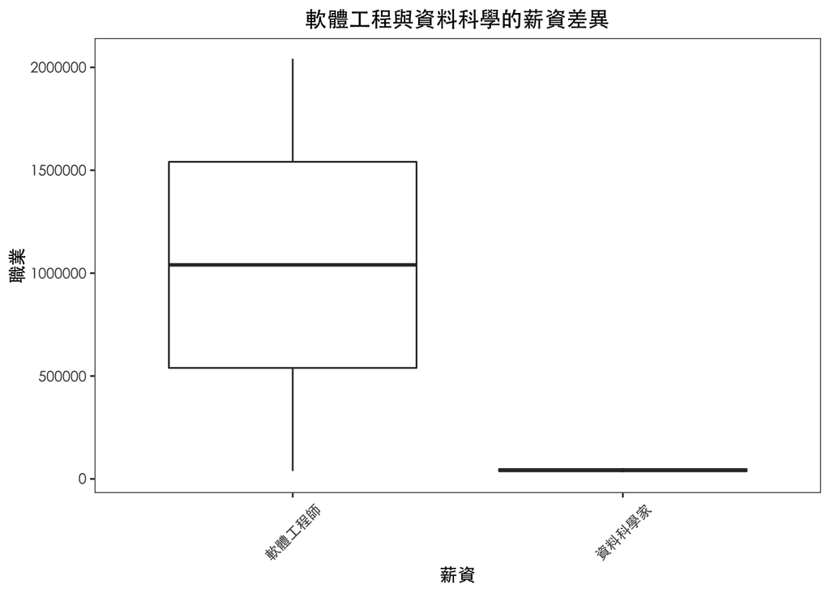

```r
### your code
####抓資料
refer_softurl <- "https://www.104.com.tw/jobs/search/?keyword=%E8%BB%9F%E9%AB%94%E5%B7%A5%E7%A8%8B&order=1&jobsource=2018indexpoc&ro=0"
soft_url <- "https://www.104.com.tw/jobs/search/list?ro=0&kwop=7&keyword=%E8%BB%9F%E9%AB%94%E5%B7%A5%E7%A8%8B&expansionType=area%2Cspec%2Ccom%2Cjob%2Cwf%2Cwktm&order=12&asc=0&page=2&mode=s&jobsource=2018indexpoc&langFlag=0&langStatus=0&recommendJob=1&hotJob=1"

res_soft <- GET(soft_url, add_headers("referer"=refer_softurl)) %>%
            content("text") %>%
            fromJSON()

soft.df <- res_soft$data$list

#save(soft.df, file='soft.df.rda')

data_url <- "https://www.104.com.tw/jobs/search/list?ro=0&kwop=7&keyword=%E8%B3%87%E6%96%99%E7%A7%91%E5%AD%B8&expansionType=area%2Cspec%2Ccom%2Cjob%2Cwf%2Cwktm&order=12&asc=0&page=2&mode=s&jobsource=2018indexpoc&langFlag=0&langStatus=0&recommendJob=1&hotJob=1"

refer_dataurl <- "https://www.104.com.tw/jobs/search/?keyword=%E8%B3%87%E6%96%99%E7%A7%91%E5%AD%B8&order=1&jobsource=2018indexpoc&ro=0"

res_data <- GET(data_url, add_headers("referer"=refer_dataurl)) %>%
            content("text") %>%
            fromJSON()

data.df <- res_data$data$list

#save(data.df, file='data.df.rda')

####清理資料
soft.df <-  soft.df %>%
    select(jobName,salaryLow,salaryHigh)

 data.df <- data.df %>%
  select(jobName,salaryLow,salaryHigh)


all.df <- full_join(soft.df,data.df) %>%
   mutate(`最低薪資` = as.numeric(`salaryLow`),
               `最高薪資` = as.numeric(`salaryHigh`)) %>%
   select(-(2:3)) %>%
   filter(`最低薪資` > 0 & `最高薪資` >0) %>%
   mutate(`jobName` = str_remove_all(`jobName`, "iOS")) %>%
   mutate(`jobName` = str_remove_all(`jobName`, " ")) %>%
   mutate(`jobName` = str_remove_all(`jobName`, " ")) %>%
   mutate(`jobName` = str_remove_all(`jobName`, "AI")) %>%
   mutate(`jobName` = str_remove_all(`jobName`, "3D")) %>%
   mutate(`jobName` = str_remove_all(`jobName`, "DataScientist")) %>%
   mutate(`jobName` = str_remove_all(`jobName`, "   【產品處】AI工程師/")) %>%
   mutate(`jobName` = str_remove_all(`jobName`, "/機器學習工程師(可遠端作業)")) %>%
   mutate(`jobName` = str_remove_all(`jobName`, "   DataScientist/")) %>%
   mutate(`jobName` = str_remove_all(`jobName`, "(DataScientist)")) %>%
   mutate(`jobName` = str_remove_all(`jobName`, "DataScientist/")) %>%
   mutate(`jobName` = str_remove_all(`jobName`, "_11060")) %>%
   mutate(`jobName` = str_remove_all(`jobName`, "/")) %>%
  filter(`jobName` == "軟體工程師" | `jobName` == "資料科學家") %>%
   group_by(`jobName`) %>%
   summarise(`平均最低薪資` = mean(`最低薪資`),
             `平均最高薪資` = mean(`最高薪資`)) %>%
   ungroup()  %>%
   pivot_longer(cols = -jobName, names_to = "薪資", values_to = "value")

all.df %>%
  ggplot(aes(x = `jobName`,  y = `value`)) +
  geom_boxplot() + # 箱形圖
  xlab("職業") +   # X 軸標示文字
  ylab("薪資") +  # Y 軸標示文字
  theme_bw() +
  theme(panel.grid.major = element_blank(),
         panel.grid.minor = element_blank()) +
    labs(title = '軟體工程與資料科學的薪資差異', x = "薪資", y = "職業") +
    theme(text=element_text(family="黑體-繁 中黑"),
    axis.text.x = element_text(angle = 45, vjust = 0.5),
    plot.title = element_text(hjust = 0.5))
```

## B. scrape google trend（50分）

### (1) scraping（30分）

請到 [Google 每日搜尋趨勢](https://trends.google.com.tw/trends/trendingsearches/daily?geo=TW)，以**抓取 JSON 的方式**，爬下最近一週的搜尋趨勢結果，這裡的一週沒有規定具體日期，從你做作業當天為基礎即可。這題一樣建議你爬好資料之後，可以自行創建並存取在 `data/AS05/` 資料夾當中，以免每次 knit 都要重爬。

結果部分請加入**日期**欄位，先印出前 10 個列，接著印出各個日期的筆數（參考程式碼：`df %>% count(date)`）。

提示： a. API url 的長相類似這樣 - “https://trends.google.com.tw/trends/api/”，後面還有東西，可以去找一下  
b. 可以用迴圈寫，並且在迴圈中更新 API url 的日期  
c. 直接用 `fromJSON()` 會出事，因為 Google 很壞，它故意在結果的前 5 個字塞入不相干的東西阻礙你，建議你可以用 `str_sub()` 抓取正確的字串再轉換成 JSON

```r
### your code
google.df <- tibble()

google_url <- "https://trends.google.com.tw/trends/api/dailytrends?hl=zh-TW&tz=-480&ed=20220501&geo=TW&ns=15"


#google <- GET(google_url) %>%content("text") %>%fromJSON()


for(p in 20220423:20220430){
   google_url <- str_c("https://trends.google.com.tw/trends/api/dailytrends?hl=zh-TW&tz=-480&ed=",
                        p,
                        "&geo=TW&ns=15")
  print(p)

  res_google <-  GET(google_url,add_headers("Referer"=google_url)) %>%
      content("text") %>%
      str_sub(6)%>%
      fromJSON()
google.res <- res_google$default$trendingSearchesDays$trendingSearches


}

# unlist data structure to a list
google.res <- unlist(google.res)
head(google.res)

# anyNA() to check if NAs still exist
anyNA(google.res)

# (option) check if NAs exist
sum(is.na(google.res))

# remove NAs
google.res<- google.res[!is.na(google.res)]
# length(safefood.v)

# double-check NAs
anyNA(google.res)
head(google.res)


# convert vector to matrix
google.m <- matrix(google.res, byrow = T, ncol = 6)
# ?matrix

# convert matrix to dataframe
google.res.df <- as.data.frame(google.m)






### result 01
```

[output not shown]

```r
### result 02
```

[output not shown]

[output not shown]

### (2) cleaning（20分）

這個資料的原始結構有點複雜，請嘗試列出 `id`, `date`, `query`, `formattedTraffic`, `title`, `source`, `url`, `snippet` 等欄位。其中，`id` 和 `date` 是自行加入的欄位，其他都是上一小題就能抓到的結果。這題比較難，所以配分低一些。

提示： a. `id`: 可以利用 `mutate(id = row_number())`  
b. 原始的 dataframe 不是一般常見的 dataframe，有些 column 本身是 list，又被稱為 nested dataframe，處理起來很麻煩，建議可以用 `$`  
c. 會用到 2 次 `left_join()`

```r
### your code

### result
```

[output not shown]